# Homework 2

STAT 399: Statistical Computing and Data Visualization with R

Do not include your name, keep anonymous for peer review

Due: Wednesday 4/29/2020 by 12:00 pm

## Instructions

- Make a copy of this template to write out your solution, and simply knit it as `HW02.Rmd`.
- Inside this .Rmd file do not include any personal identifier (such as your name, Odin ID, etc.).
- Knit your Rmd file as html and upload both the Rmd and html files with your solution to D2L in `Activities > Assignments > Homework2` before Wednesday April 29th at 12:00 pm.

## Objectives for this week’s homework

1. Practice making figures in both base R and ggplot2
2. Generate hypotheses and explore them graphically

Write down a question or hypothesis you are interested in exploring from the *world powerplant dataset* I found in the [information is beautiful](https://informationisbeautiful.net/visualizations/mega-what-the-worlds-biggest-and-most-notable-power-plants/) webpage, which includes some nice visualizations. The original data can be found [here](http://datasets.wri.org/dataset/globalpowerplantdatabase) along with a brief description of the data. Note that inside of the globalpowerplant folder in RStudio Cloud (as well as in the D2L the homework folder) I provide additional documents with information that may prove useful, in particular be sure to look at the `README.txt` file, which includes the metadata (a description of the variables) in the **Fields** section.

The idea is for you to investigate your question/hypothesis graphically. To do so, generate the figures you consider necessary – at least two and at most 4, and note that more figures is not necessarily better, fewer but very well though-out and informative figures might do the trick. The only condition is that at least one of your figures is built using `base R` and at least one is built in `ggplot2`.*

You might want to work with just a subset of the data (e.g. one particular country), or you may choose to transform or summarize your data in the way that best allows you to explore your question. All titles, axes, and legends should be labelled clearly (no raw variable names). You must have at least one graph with `facet_wrap` or `facet_grid`. You must include at least one manually specified legend. You can use other `geoms` like histograms, bar charts, add vertical or horizontal lines, etc. [You may find this data visualization cheat sheet helpful](https://www.rstudio.com/wp-content/uploads/2016/11/ggplot2-cheatsheet-2.1.pdf).

Your document should be aesthetically pleasing, with some organization. You must write up your observations in words as well as showing the graphs. Use chunk options `echo` and `results` to limit the code/output you show in the `.html`.

Below I load n the data, but be careful, you may need to filter out rows that have `NA`s in some of specific variables, so recall that you can test (and filter out) for `NAs` using the function `is.na`, which is vectorized (look at week 2’s classnotes)!

Have fun and Good Luck!!

```r
power <- read.csv('globalpowerplant/global_power_plant_database.csv',
                  na.strings = c(NA,"","NA"),
                  header=T)
str(power)
```

```
## 'data.frame':    29910 obs. of  24 variables:
##  $ country                 : Factor w/ 164 levels "AFG","AGO","ALB",..: 1 1 1 1 1 1 1 3 3 3 ...
##  $ country_long            : Factor w/ 164 levels "Afghanistan",..: 1 1 1 1 1 1 1 2 2 2 ...
##  $ name                    : Factor w/ 29538 levels "'Muela","10 De Octubre (nuevitas) Powerplant",..: 12986 15750 17484 17559 18273 20910 23025 2568 8158 13664 ...
##  $ gppd_idnr               : Factor w/ 29910 levels "ARG0000001","ARG0000002",..: 7014 7016 7010 7012 7015 7013 7011 17741 17742 17743 ...
##  $ capacity_mw             : num  33 66 100 11.6 42 ...
##  $ latitude                : num  32.3 34.6 34.6 34.5 34.6 ...
##  $ longitude               : num  65.1 69.5 69.7 70.4 69.1 ...
##  $ primary_fuel            : Factor w/ 15 levels "Biomass","Coal",..: 6 6 6 6 4 6 6 6 6 6 ...
##  $ other_fuel1             : Factor w/ 12 levels "Biomass","Coal",..: NA NA NA NA NA NA NA NA NA NA ...
##  $ other_fuel2             : Factor w/ 11 levels "Biomass","Coal",..: NA NA NA NA NA NA NA NA NA NA ...
##  $ other_fuel3             : Factor w/ 7 levels "Biomass","Gas",..: NA NA NA NA NA NA NA NA NA NA ...
##  $ commissioning_year      : num  NA NA NA NA NA ...
##  $ owner                   : Factor w/ 9565 levels "1","1 Solar Energie as",..: NA NA NA NA NA NA NA NA NA NA ...
##  $ source                  : Factor w/ 865 levels "4C Offshore",..: 270 270 270 270 270 270 270 219 219 219 ...
##  $ url                     : Factor w/ 4869 levels "ftp://ftp.maps.canada.ca/pub/nacei_cnaie/energy_infrastructure/PowerPlantsRenewGE1MW_NorthAmerica_201708.xlsx",..: 199 199 199 199 199 199 199 1029 1029 1029 ...
##  $ geolocation_source      : Factor w/ 27 levels "AgÃªncia Nacional de Energia ElÃ©trica (Brazil)",..: 11 11 11 11 11 11 11 11 11 11 ...
##  $ wepp_id                 : Factor w/ 15399 levels "1002121","1008913",..: 34 35 36 33 NA NA 37 2141 2142 2143 ...
##  $ year_of_capacity_data   : int  2017 2017 2017 2017 2017 2017 2017 NA NA NA ...
##  $ generation_gwh_2013     : num  NA NA NA NA NA NA NA NA NA NA ...
##  $ generation_gwh_2014     : num  NA NA NA NA NA NA NA NA NA NA ...
##  $ generation_gwh_2015     : num  NA NA NA NA NA NA NA NA NA NA ...
##  $ generation_gwh_2016     : num  NA NA NA NA NA NA NA NA NA NA ...
##  $ generation_gwh_2017     : num  NA NA NA NA NA NA NA NA NA NA ...
##  $ estimated_generation_gwh: num  NA NA NA NA NA ...
```

# Global Power Distribution

It would be interesting to look at graphically the distribution of power generation and what type of power is used through the world.

We’ll use the `maps` package to be able to draw the world map, then use the gps coordinates to place the points. Each point will be a bubble size of generation capacity, and the color of the bubble will represent the primary fuel source.

First start out being able to make a map

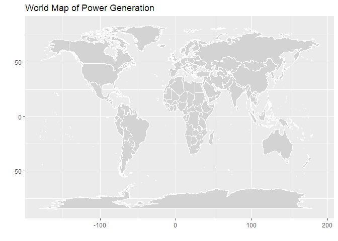

```r
world_map <- map_data("world")
ggplot(world_map, aes(x=long, y=lat, group=group)) +
  geom_polygon(fill="lightgray", colour="white") +
  xlab("") + ylab("") +
  theme(legend.position = "none") +
  ggtitle("World Map of Power Generation")
```

Originally I wanted to merge the map data and the data for power plants. To do this we’ll run some selection on the `power` dataframe and rename the `country_long` column to the `country` column and follow that by a left outer join. This turned out to be a bit unwieldly, giving us some 38 million observations. Instead I found that I can overlay the two using the same coordinate conversion.

Next we take care of cleaning up the generation data. Some rows have NA across the board, these we will want to preserve the NAness of it to remove them from further processing, but for the ones that have at least one value in the years we’ll or the estimated amount, we’ll want to calculate a column that uses the available information.

To do this we’ll make a function, then apply it as a new column to a new dataframe.

```r
# This will be used to add a new column to the power generation data frame by performing
# some guessing of values using their mean. This should increase the number of rows with
# a representative. Some rows have no such data and we can use na.omit to rid ourself of
# those.
estimated_power <- function( x ){
  if(!is.na(x["estimated_generation_gwh"])){
    return(x["estimated_generation_gwh"])
  }

  cols <- paste("generation_gwh",2013:2017,sep="_")

  generation <- unlist(x[cols])
  if(sum(!is.na(generation))){
    return(mean(generation,na.rm=TRUE))
  }else{
    return(NA_real_)
  }
}
```

Now let’s test this out first on a subset of the data as this will be faster than running it over the entire data frame while debugging.

```r
# Appraently `apply` coerces each row into a vector rather than a list
# This then causes a bunch of headaches with it returning a character type vector
# whereas I want a numeric type
# by passing in only the numeric columns I need for the function it works without a lot of
# double checking in the function.
cols <- c( "estimated_generation_gwh", paste("generation_gwh",2013:2017,sep="_"))
result <- apply( power[sample(seq_along(1:nrow(power)), size=10 ), cols], 1, FUN=estimated_power )

str(result)
```

```
##  Named num [1:10] 51.3 NA 33.4 18.1 220.4 ...
##  - attr(*, "names")= chr [1:10] "24329" "8100" "19526" "20436" ...
```

We’ve tested this out on a random sample, now we’ll try this out on the full set. We’ll also make some splits on the data for generation as there are some plants that make less energy than they expend, some are neutral, and most create more energy than they expend.

```r
powermap <- cbind( power[,c("country_long","longitude", "latitude","primary_fuel")], mean_generation_gwh=apply(power[,cols], 1, FUN=estimated_power ) )
names(powermap)[names(powermap) == "country_long"] <- "region"

pmap.power <- na.omit(powermap)
pmap.positive.power <- pmap.power[which(pmap.power$mean_generation_gwh > 0),]
pmap.negative.power <- pmap.power[which(pmap.power$mean_generation_gwh < 0),]
pmap.neutral.power <- pmap.power[which(pmap.power$mean_generation_gwh ==0),]
pmap.world <- world_map[,c("long", "lat", "group", "order", "region")]
```

Since we’re going to be making a few maps that are the same but for the data they work on we’ll make a function factory to do this for us.

```r
plot_data <- function( data, map_plot ){
  ggplot() +
  geom_polygon( data=map_plot, aes(x=long, y=lat, group=group), fill="lightgray" ) +
  theme(axis.ticks.y = element_blank(), axis.text.y = element_blank(),
        axis.ticks.x = element_blank(), axis.text.x = element_blank() ) +
  xlab("") + ylab("") +
  geom_point(data=data,aes(x=longitude, y=latitude, color = primary_fuel, size = mean_generation_gwh), alpha=0.25, ) +
    labs(color="Primary Fuel") +
  theme(legend.position = "top")
}
```

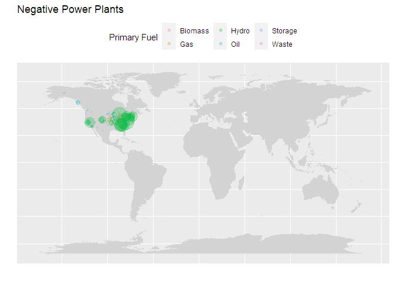

```r
pmap.negative.map <- plot_data(pmap.negative.power, pmap.world) +
  scale_size_continuous(range = c(.1, 10), trans = "reverse", guide=(All=FALSE)) +
  ggtitle("Negative Power Plants")
pmap.neutral.map <- plot_data(pmap.neutral.power, pmap.world) +
  scale_size(guide=(All=FALSE)) +
  ggtitle("Neutral Power Plants")
pmap.positive.map <- plot_data(pmap.positive.power, pmap.world) +
  scale_size_continuous(range = c(.1, 10), trans = "identity", guide=(All=FALSE)) +
  ggtitle("Positive Power Plants")
pmap.negative.map
```

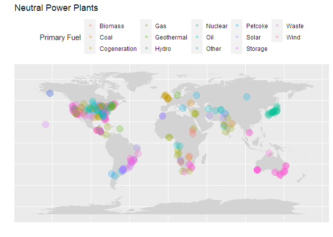

```r
pmap.neutral.map
```

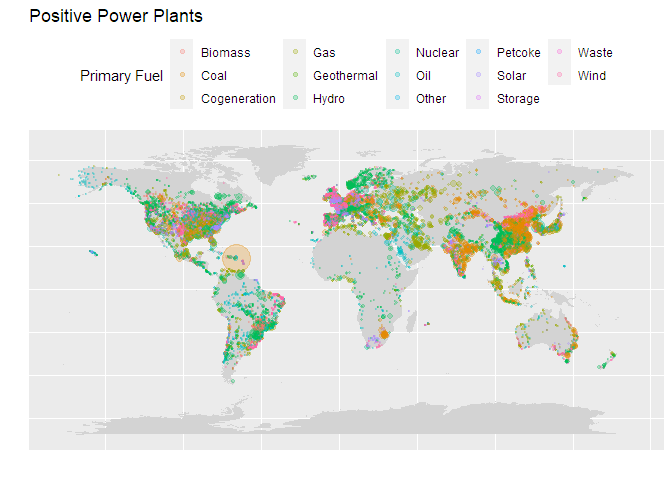

```r
pmap.positive.map
```

Seems that the only place in the world with negative power plants are in the US and maybe canada.

Let’s try to use `facet_wrap` to split this up rather than splitting it ourselves into three different diagrams.

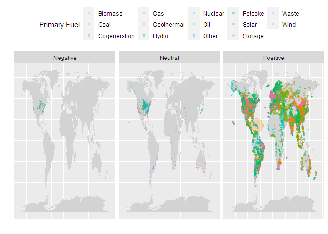

```r
# Create the labels for the facets
facet_labels <- c("Negative","Neutral","Positive")
names(facet_labels) <- c("(-5e+04,-0.1]","(-0.1,0.1]","(0.1,5e+07]")

pmap.map <- plot_data(transform(pmap.power, fct = cut(mean_generation_gwh, c(-5e+04,-1e-01,1e-01,5e+07))), pmap.world)
pmap.primary_fuel_facet <- pmap.map +
  scale_size_continuous(range = c(.1, 10), trans = "identity", guide=(All= FALSE) ) +
  facet_wrap(~fct, labeller=labeller(fct=facet_labels))

pmap.primary_fuel_facet
```

This is looking nice, but it’s a bit clutered and hard to really understand anything from it. Unfortunately this doesn’t have a column called “Continent” or else we would create some facets based on continent to hopefully have a better view. Instead we’ll make our own grouping of energy categories and do a left-join onto it.

```r
# Gather the primary_fuel factor
unique(pmap.power$primary_fuel)
```

```
##  [1] Hydro        Other        Gas          Oil          Nuclear
##  [6] Coal         Solar        Wind         Waste        Biomass
## [11] Petcoke      Geothermal   Cogeneration Storage
## 15 Levels: Biomass Coal Cogeneration Gas Geothermal Hydro Nuclear Oil ... Wind
```

We’ll create a data frame from the `primary_fuel` factors, then bind our categorization onto it.

```r
pf = data.frame(primary_fuel=unique(pmap.power$primary_fuel))
pf = cbind(pf, fuel_category=c("Green", "Unknown", "Black", "Black", "Green", "Black",
                               "Green", "Green", "Unknown", "Green", "Black", "Green",
                               "Green", "Unknown"))
```

Now we can left join it with our data.

```r
pmap.category_power <- left_join(pmap.power, pf, by=c("primary_fuel"))
```

With the data joined we can now facet on this new category to create three world maps.

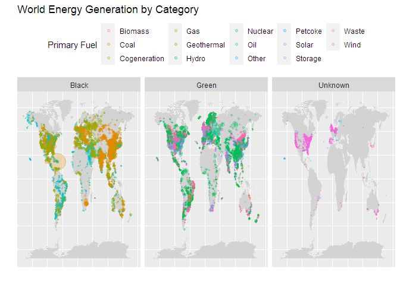

```r
pmap.map <- plot_data(pmap.category_power, pmap.world)
pmap.primary_fuel_category_facet <- pmap.map +
  scale_size_continuous(range = c(.1, 10), trans = "identity", guide=(All= FALSE) ) +
  facet_wrap(~fuel_category) +
  ggtitle("World Energy Generation by Category")

pmap.primary_fuel_category_facet
```

Now we’re sort of getting somewhere, we see a large distribution of black and green energy throughout the globe. Even though it’s an interesting looking plot, it doesn’t really tell us much.

Let’s take a closer look at a familiar region, the USA. We’ll splice out the data, and from a couple tries I found that limiting the longitude removed one of the US Territories that was a bit out of range for our map.

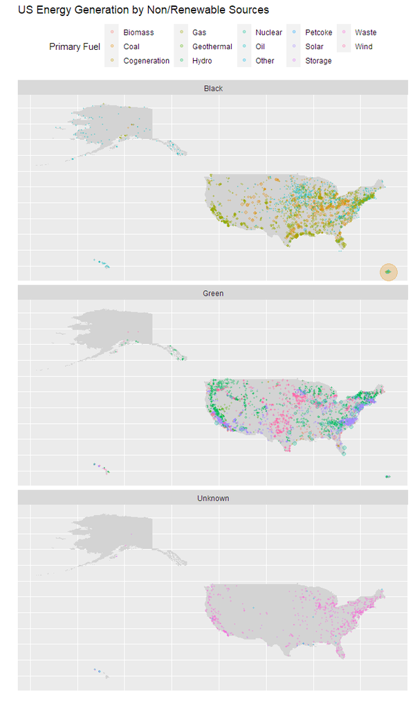

```r
pmap.usa <- plot_data(pmap.category_power[which(pmap.category_power$region=="United States of America" & pmap.category_power$longitude < 144),], pmap.world[which(pmap.world$region=="USA" & pmap.world$long < 144),])
pmap.usa_primary_fuel_category_facet <- pmap.usa +
  scale_size_continuous(range = c(.1, 10), trans = "identity", guide=(All= FALSE) ) +
  facet_wrap(~fuel_category, ncol=1) +
  ggtitle("US Energy Generation by Non/Renewable Sources")

pmap.usa_primary_fuel_category_facet
```

This one shows us visually the concentration of power generation by fuel type category. Here we see a green suspender going up the West Coast. We also notice there are some areas where black energy sources are not present but green sources are, especially in the mid-west.

## Total Energy Generation Year by Year

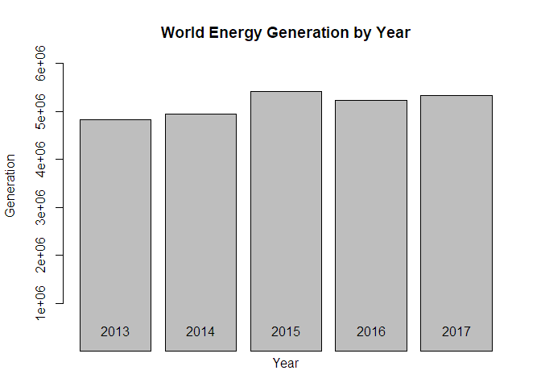

```r
baser.cols <- c(paste("generation_gwh", 2013:2017, sep="_" ))
baser.power <- power[,baser.cols]
baser.byyear <- apply(baser.power, 2, sum, na.rm=TRUE)
baser.df <- data.frame(Year=c(2013:2017))
baser.df <- cbind(baser.df, Generation=baser.byyear )

barplot(Generation ~ Year, data=baser.df,
        ylim=c(9e+5,6e+6),
        xlab = "Year",
        ylab = "Generation")
title("World Energy Generation by Year")
```